# LoanPredictor

## Loan Prediction with Python

This tutorial is based on the course Loan Prediction with Python

### 1. Problem statement

> *Dream Housing Finance company deals in all home loans. They have presence across all urban, semi urban and rural areas. Customer first apply for home loan after that company validates the customer eligibility for loan. Company wants to automate the loan eligibility process (real time) based on customer detail provided while filling online application form. These details are Gender, Marital Status, Education, Number of Dependents, Income, Loan Amount, Credit History and others. To automate this process, they have given a problem to identify the customers segments, those are eligible for loan amount so that they can specifically target these customers.*

> *From the above statement, we understand that the goal is to predict which loan applicants will be approved*

### 2. Generating Hypotheses

A crucial step in any model building is to generate a set of hypotheses. Just like [hypothesis testing](http://www.statisticshowto.com/probability-and-statistics/hypothesis-testing/) in statistics, it's important that this be done prior to diving into the data. So we may ask **How would a customer details affect loan approval?** Here are my own hypotheses:

> - Married people would have a higher chance of being approved compared to single applicants.
> - Approval probability will increase with the level of education and with higher credit score.
> - The higher in income, the higher the probability of being approved for a loan.
> - Approval probability will decrease with the loan amount.
> - There will be an age group dependence:
>   - Apporval probability for people in their early 20's will be lower than people in their 30's-40's.
>   - Old and retired people will have a lower chance of approval.
> - People who possess other assets such as bussinesses may have higher chance of approval.
> - Certain people such as government employees may be considered to have more stable job(income), hence greater chance of approval compared to others such as contractors.

### Import Libraries

```python
import pandas as pd
import numpy as np
import seaborn as sns

import matplotlib.pyplot as plt
%matplotlib inline

from IPython.core.interactiveshell import InteractiveShell
InteractiveShell.ast_node_interactivity = "last_expr"
pd.options.display.max_columns = 50

import warnings
warnings.filterwarnings("ignore")
```

### Load The Data

```python
#parse the data into pandas dataframes
loan_train = pd.read_csv('data/train_u6lujuX_CVtuZ9i.csv')
loan_test = pd.read_csv('data/test_Y3wMUE5_7gLdaTN.csv')

#make a safe copy of dataframes
loan_train_original = loan_train.copy()
loan_test_original = loan_test.copy()
train_id = loan_train.Loan_ID
test_id = loan_test.Loan_ID
labels = loan_train.Loan_Status
loan_train.head()
```

|  | Loan_ID | Gender | Married | Dependents | Education | Self_Employed | ApplicantIncome | CoapplicantIncome | LoanAmount | Loan_Amount_Term | Credit_History | Property_Area | Loan_Status |
| --- | --- | --- | --- | --- | --- | --- | --- | --- | --- | --- | --- | --- | --- |
| 0 | LP001002 | Male | No | 0 | Graduate | No | 5849 | 0.0 | NaN | 360.0 | 1.0 | Urban | Y |
| 1 | LP001003 | Male | Yes | 1 | Graduate | No | 4583 | 1508.0 | 128.0 | 360.0 | 1.0 | Rural | N |
| 2 | LP001005 | Male | Yes | 0 | Graduate | Yes | 3000 | 0.0 | 66.0 | 360.0 | 1.0 | Urban | Y |
| 3 | LP001006 | Male | Yes | 0 | Not Graduate | No | 2583 | 2358.0 | 120.0 | 360.0 | 1.0 | Urban | Y |
| 4 | LP001008 | Male | No | 0 | Graduate | No | 6000 | 0.0 | 141.0 | 360.0 | 1.0 | Urban | Y |

### Feature Analysis

```python
def df_infos(df):

    print('Dataframe dimensions:', df.shape)
    #____________________________________________________________
    # gives some infos on columns types and number of null values

    df_info = pd.DataFrame(df.dtypes).T.rename(index={0:'column type'})
    df_info = df_info.append(pd.DataFrame(df.isnull().sum()).T.rename(index={0:'null values'}))
    df_info = df_info.append(pd.DataFrame(df.isnull().sum()/df.shape[0]*100)
                         .T.rename(index={0:'null values (%)'}))
    return df_info
```

```python
#shape of dataframe
df_infos(loan_train)
```

```
Dataframe dimensions: (614, 13)
```

|  | Loan_ID | Gender | Married | Dependents | Education | Self_Employed | ApplicantIncome | CoapplicantIncome | LoanAmount | Loan_Amount_Term | Credit_History | Property_Area | Loan_Status |
| --- | --- | --- | --- | --- | --- | --- | --- | --- | --- | --- | --- | --- | --- |
| column type | object | object | object | object | object | object | int64 | float64 | float64 | float64 | float64 | object | object |
| null values | 0 | 13 | 3 | 15 | 0 | 32 | 0 | 0 | 22 | 14 | 50 | 0 | 0 |
| null values (%) | 0 | 2.11726 | 0.488599 | 2.443 | 0 | 5.21173 | 0 | 0 | 3.58306 | 2.28013 | 8.14332 | 0 | 0 |

```python
# basic statistics
loan_train.describe()
```

|  | ApplicantIncome | CoapplicantIncome | LoanAmount | Loan_Amount_Term | Credit_History |
| --- | --- | --- | --- | --- | --- |
| count | 614.000000 | 614.000000 | 592.000000 | 600.00000 | 564.000000 |
| mean | 5403.459283 | 1621.245798 | 146.412162 | 342.00000 | 0.842199 |
| std | 6109.041673 | 2926.248369 | 85.587325 | 65.12041 | 0.364878 |
| min | 150.000000 | 0.000000 | 9.000000 | 12.00000 | 0.000000 |
| 25% | 2877.500000 | 0.000000 | 100.000000 | 360.00000 | 1.000000 |
| 50% | 3812.500000 | 1188.500000 | 128.000000 | 360.00000 | 1.000000 |
| 75% | 5795.000000 | 2297.250000 | 168.000000 | 360.00000 | 1.000000 |
| max | 81000.000000 | 41667.000000 | 700.000000 | 480.00000 | 1.000000 |

**Summary of Feature Type Analysis**

> We do have a number of numeric and non-numeric features, and some features do have missing values. This tells us that we will have to think about:
> - **Feature Encoding** (label encoding, one-hot encoding, mean encoding?)
> - **Missing value imputation** (what will be the appropriate method for each feature?)
> - **Feature scaling** (Numeric features span widely different ranges)

### Check for Class Imbalance

```python
#check clas balance
def class_proportion(df, target='Loan_Status'):

    n_sample = len(df)
    positive = sum(df[target] == 'Y')
    negative = sum(df[target] == 'N')
    print("proportion positive class = {:.2f}".format(positive/n_sample))
    print("proportion negative class = {:.2f}".format(negative/n_sample))
```

```python
print("Checking class imbalance in the train set:")
class_proportion(loan_train, target='Loan_Status')
```

```
Checking class imbalance in the train set:
proportion positive class = 0.69
proportion negative class = 0.31
```

**Summary for Class Imbalance**  
There is more of the positiove class than the negative class. i.e. The current dataset has more examples for which the class label is positive. We should keep this in mind when selecting and evaluating the model. Which type of metric should be used? Accuracy score? Confusion Matrix?

**Note:** Logistic Regression for instance tends to predict thesame class when the data has high class imbalance. We should consider setting the variable **class_weight = balanced** or other values has appropriate in this case.

### Data Exploration

Here is a list of features and their meaning:

| Variable | Description |
| --- | --- |
| Loan_ID | Unique Loan ID |
| Gender | Male/Female |
| Married | Applicant married (Y/N) |
| Dependents | Number of dependents |
| Education | Education (Graduate/ Under Graduate) |
| Self_Employed | Self employed (Y/N) |
| ApplicantIncome | Applicant income |
| CoapplicantIncome | Coapplicant income |
| LoanAmount | Loan amount in thousands |
| Loan_Amount_Term | Term of loan in months |
| Credit_History | credit history meets guidelines |
| Property_Area | Urban/ Semi Urban/ Rural |
| Loan_Status | Loan approved (Y/N) |

Now let's go through each of our initial hypothesis and see if they agree with the data

#### 1. Loan Status vs Marital Status

###### Married applicants would have a higher chance of being approved compared to single applicants

```python
def make_table(df_train, column, target='Loan_Status', groups=['Yes','No']):

    """utility function to print a summary table for a specified column
    """

    df = df_train[[column, target]].groupby(column).count()
    df.columns = ["Count"]
    df['Approved'] = 0
    df['Proportion Approved'] = 0

    group1, group2 = groups[0], groups[1]

    #find the number of approved married people
    married_approved = (df_train[column]==group1) & (df_train[target]=='Y')
    df.loc[group1, 'Approved'] = len(df_train[married_approved])

    #find the number of approved single people
    single_approved = (df_train[column]==group2) & (df_train[target]=='Y')
    df.loc[group2, 'Approved'] = len(df_train[single_approved])

    df.loc[group1, 'Proportion Approved'] = df.loc[group1, 'Approved']/df.loc[group1, 'Count']
    df.loc[group2, 'Proportion Approved'] = df.loc[group2, 'Approved']/df.loc[group2, 'Count']
    return df
```

```python
df = make_table(loan_train, column='Married', target='Loan_Status', groups=['Yes','No'])
df
```

| Married | Count | Approved | Proportion Approved |
| --- | --- | --- | --- |
| No | 213 | 134 | 0.629108 |
| Yes | 398 | 285 | 0.716080 |

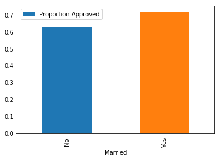

```python
ax = df['Proportion Approved'].plot(kind='bar', legend=True)
```

**Summary of Marital Status vs Loan Approval**

<hr style="height:1px";>

> We see that there are more married (398) applicants than single (213) applicants. We also find that the proportion of married applicants that got approved was higher than the proportion of single applicants that got approved. This seems to agree with our initial hypothesis. We may perform a more rigourous statistical tests to confirm that the difference in proportions is indeed significant.

<hr style="height:1px";>

#### 2. Loan Status vs Level of Education

###### More educated applicants will have a higher chance of being approved

```python
# Check unique classes for variable Education
print("Unique calsses for variable Education", loan_train['Education'].unique())
df = make_table(loan_train,
                column='Education',
                target='Loan_Status',
                groups=['Graduate', 'Not Graduate'])
df
```

```
Unique calsses for variable Education ['Graduate' 'Not Graduate']
```

| Education | Count | Approved | Proportion Approved |
| --- | --- | --- | --- |
| Graduate | 480 | 340 | 0.708333 |
| Not Graduate | 134 | 82 | 0.611940 |

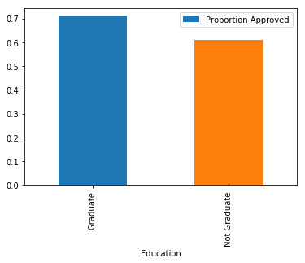

```python
#plot
ax = df['Proportion Approved'].plot(kind='bar', legend=True)
```

#### 3. Loan Status vs Credit History

###### Applicants with higher credit scores will have a higher chance of being approved

```python
# Check unique classes for variable Credit history
print("Unique calsses for variable Education", loan_train['Credit_History'].unique())
df = make_table(loan_train,
                column='Credit_History',
                target='Loan_Status',
                groups=[1, 0])
df
```

```
Unique calsses for variable Education [ 1.  0. nan]
```

| Credit_History | Count | Approved | Proportion Approved |
| --- | --- | --- | --- |
| 0.0 | 89 | 7 | 0.078652 |
| 1.0 | 475 | 378 | 0.795789 |

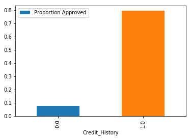

```python
#plot
ax = df['Proportion Approved'].plot(kind='bar', legend=True)
```

**Summary of Education and Credit Score vs Loan Status**

<hr style="height:1px";>

> It appears that:
> - The level of education favors loan approval
> - Credit history is very important for loan approval

<hr style="height:1px";>

#### 4. Is there a gender bias?

```python
df = make_table(loan_train,
                column='Gender',
                target='Loan_Status',
                groups=['Male', 'Female'])
df
```

| Gender | Count | Approved | Proportion Approved |
| --- | --- | --- | --- |
| Female | 112 | 75 | 0.669643 |
| Male | 489 | 339 | 0.693252 |

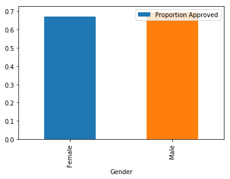

```python
#plot
ax = df['Proportion Approved'].plot(kind='bar', legend=True)
```

```python
#use crosstap() to to perform same task as previous step
Gender=pd.crosstab(loan_train['Gender'],loan_train['Loan_Status'])
Gender
```

| Loan_Status Gender | N | Y |
| --- | --- | --- |
| Female | 37 | 75 |
| Male | 150 | 339 |

```python
#Find proportions by normalizing row-wise
Gender.div(Gender.sum(axis=1).astype(float), axis=0)
```

| Loan_Status Gender | N | Y |
| --- | --- | --- |
| Female | 0.330357 | 0.669643 |
| Male | 0.306748 | 0.693252 |

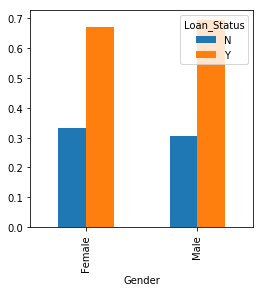

```python
#Same as above, but use the normalize argument of crosstab()
(pd.crosstab(loan_train['Gender'],loan_train['Loan_Status'], normalize='index').
    plot(kind="bar", stacked=False, figsize=(4,4)) )
```

#### 5. Property Area vs Loan Status

##### Does the location of the property in question affect loan approval?

```python
#Same as above, but use the normalize argument of crosstab()
df = pd.crosstab(loan_train['Property_Area'],loan_train['Loan_Status'], normalize='index').sort_values(by='Y')
df
```

| Loan_Status Property_Area | N | Y |
| --- | --- | --- |
| Rural | 0.385475 | 0.614525 |
| Urban | 0.341584 | 0.658416 |
| Semiurban | 0.231760 | 0.768240 |

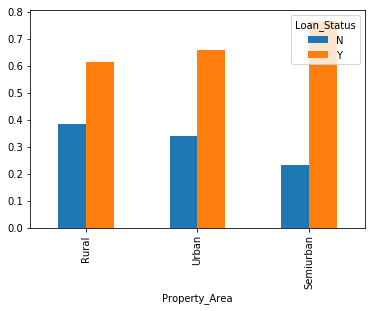

```python
ax = df.plot(kind='bar', stacked=False)
```

**Summary of Property Area vs Loan Status**

<hr style="height:1px";>

> It appears that:
> - Applicant who seek loans for properties in semiurban area have a higher approval probability
> - We should use statistical test to confirm if the difference in proportion is significant

<hr style="height:1px";>

#### 5. Loan Amount vs Loan Status

##### Does the amount requested affect loan approval?

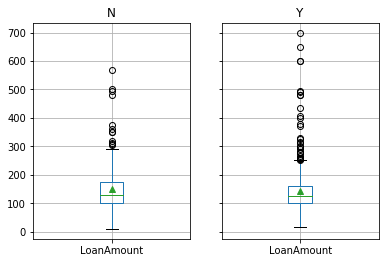

```python
_ = loan_train[['LoanAmount', 'Loan_Status']].groupby('Loan_Status').boxplot(showmeans=True)
```

> **LoanAmount** does not really tell much besides that there are a number of specially high amounts that have been approved. Let's create amount categories.

```python
#use pd.cut to create categories of LoanAmount
bins = [0, 100, 200, 300, 400, 700]
group = [100, 200, 300, 400, 700]

loan_amt_cat = pd.cut(loan_train['LoanAmount'],bins,labels=group)
pd.crosstab(loan_amt_cat, loan_train['Loan_Status'], normalize='index')
```

| Loan_Status LoanAmount | N | Y |
| --- | --- | --- |
| 100 | 0.305195 | 0.694805 |
| 200 | 0.287709 | 0.712291 |
| 300 | 0.372549 | 0.627451 |
| 400 | 0.533333 | 0.466667 |
| 700 | 0.285714 | 0.714286 |

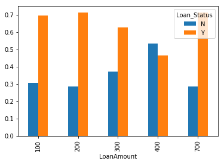

```python
_ = pd.crosstab(loan_amt_cat, loan_train['Loan_Status'], normalize='index').plot(kind='bar')
```

**Summary of Loan vs Loan Status**

<hr style="height:1px";>

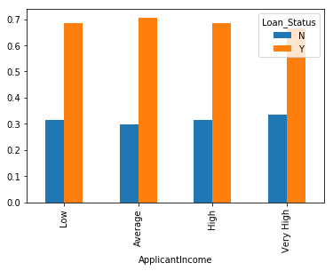

```python
bins=[0,2500,4000,6000,81000]
group=['Low','Average','High', 'Very High']
appl_income_cat = pd.cut(loan_train['ApplicantIncome'],bins,labels=group)

_= pd.crosstab(appl_income_cat,loan_train['Loan_Status'], normalize='index').plot(kind='bar')
```

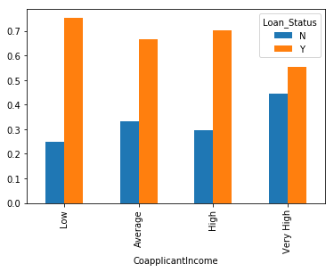

```python
#looking at the coapplicant income
bins=[0,2500,4000,6000,81000]
group=['Low','Average','High', 'Very High']
coappl_income_cat = pd.cut(loan_train['CoapplicantIncome'],bins,labels=group)

_ = pd.crosstab(coappl_income_cat,loan_train['Loan_Status'], normalize='index').plot(kind='bar')
```

```
Text(0.5,0,'TotalIncome')
```

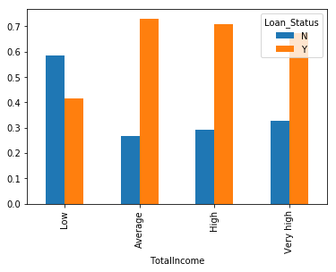

```python
#Applicant Income
tot_income = loan_train['ApplicantIncome']+loan_train['CoapplicantIncome']
bins=[0,2500,4000,6000,81000]
group=['Low','Average','High', 'Very high']
tot_income_cat = pd.cut(tot_income,bins,labels=group)

_ = pd.crosstab(tot_income_cat,loan_train['Loan_Status'], normalize='index').plot(kind='bar')
plt.xlabel('TotalIncome')
```

**Summary of Applicant-Coapplicant Income vs Loan Status**

<hr style="height:1px";>

It appears that:

- Banks consider income ranges, rather than individual income values
- Approval rate will be higher than rejection rate as long as applicant has some income
- For applicants in the low income range, approval rate increases if the coapplicant has some income
- Surprisingly, it seems that for applicants in the high income range, approval rate decreases if coapplicant also has high income
- When the total income is in the low income range, rejection rate is higher than approval rate

<hr style="height:1px";>

#### Correlation Between Features

```python
loan_train.corr()
```

|  | ApplicantIncome | CoapplicantIncome | LoanAmount | Loan_Amount_Term | Credit_History |
| --- | --- | --- | --- | --- | --- |
| ApplicantIncome | 1.000000 | -0.116605 | 0.570909 | -0.045306 | -0.014715 |
| CoapplicantIncome | -0.116605 | 1.000000 | 0.188619 | -0.059878 | -0.002056 |
| LoanAmount | 0.570909 | 0.188619 | 1.000000 | 0.039447 | -0.008433 |
| Loan_Amount_Term | -0.045306 | -0.059878 | 0.039447 | 1.000000 | 0.001470 |
| Credit_History | -0.014715 | -0.002056 | -0.008433 | 0.001470 | 1.000000 |

### Data Preparation and Cleaning

```python
#preview data again
loan_train.head(2)
```

|  | Loan_ID | Gender | Married | Dependents | Education | Self_Employed | ApplicantIncome | CoapplicantIncome | LoanAmount | Loan_Amount_Term | Credit_History | Property_Area | Loan_Status |
| --- | --- | --- | --- | --- | --- | --- | --- | --- | --- | --- | --- | --- | --- |
| 0 | LP001002 | Male | No | 0 | Graduate | No | 5849 | 0.0 | NaN | 360.0 | 1.0 | Urban | Y |
| 1 | LP001003 | Male | Yes | 1 | Graduate | No | 4583 | 1508.0 | 128.0 | 360.0 | 1.0 | Rural | N |

```python
#Loan_ID provides no information about Loaon Approval, let's drop it. We also need to drop Load_Status
loan_train_noid = loan_train.drop(['Loan_ID', 'Loan_Status'], axis=1)
loan_train_noid.head(2)
```

|  | Gender | Married | Dependents | Education | Self_Employed | ApplicantIncome | CoapplicantIncome | LoanAmount | Loan_Amount_Term | Credit_History | Property_Area |
| --- | --- | --- | --- | --- | --- | --- | --- | --- | --- | --- | --- |
| 0 | Male | No | 0 | Graduate | No | 5849 | 0.0 | NaN | 360.0 | 1.0 | Urban |
| 1 | Male | Yes | 1 | Graduate | No | 4583 | 1508.0 | 128.0 | 360.0 | 1.0 | Rural |

#### Dealing with Missing Values

> Before building any model, it's important to carefully impute missing values and also deal with outliers as appropriate. This is because missing values and outliers may affect the model performance as many machine learning algorithms do not deal missing values. We can check the number of missing values for each feature using the [pandas.isnull](https://pandas.pydata.org/pandas-docs/stable/generated/pandas.isnull.html) method which converts the dataframe into a boolean (**True** for entries that are missing and **False** for non missing entires). This [post](https://machinelearningmastery.com/handle-missing-data-python/) is useful to understand how missing values are handles in machine learning.

```python
loan_train_noid.isnull().sum(axis=0)
```

```
Gender               13
Married               3
Dependents           15
Education             0
Self_Employed        32
ApplicantIncome       0
CoapplicantIncome     0
LoanAmount           22
Loan_Amount_Term     14
Credit_History       50
Property_Area         0
dtype: int64
```

#### Numeric Features

> We can use **pd.dropna(), pd.fillna(), df.drop()** for missing value imputation. Options are:
> - Replace all missing values with the **mean, mode, or median, 0, other values**
> - Drop all rows that have missing values

> Note that when the data has outliers, **mean imputation** can be problematic since the mean is highly affected by outliers. In this case, the **median** may be a good choice, since the median is not affected by outliers.

```python
#example of median imputation for LoanAmount
loan_train_noid['LoanAmount'].fillna(loan_train_noid['LoanAmount'].median(), inplace=True)
loan_train_noid.isnull().sum(axis=0)
```

```
Gender               13
Married               3
Dependents           15
Education             0
Self_Employed        32
ApplicantIncome       0
CoapplicantIncome     0
LoanAmount            0
Loan_Amount_Term     14
Credit_History       50
Property_Area         0
dtype: int64
```

```python
numeric_features = list(loan_train_noid.dtypes[loan_train_noid.dtypes != 'object'].index)
categoric_features = list(loan_train_noid.dtypes[loan_train_noid.dtypes == 'object'].index)
test_df = loan_train_noid.copy()
for feature in numeric_features:
    test_df[feature].fillna(test_df[feature].median(), inplace=True)
test_df.isnull().sum(axis=0)
```

```
Gender               13
Married               3
Dependents           15
Education             0
Self_Employed        32
ApplicantIncome       0
CoapplicantIncome     0
LoanAmount            0
Loan_Amount_Term      0
Credit_History        0
Property_Area         0
dtype: int64
```

But missing value imputation can be done using the **sklearn Imputer class**

```python
from sklearn.base import BaseEstimator, TransformerMixin
from sklearn.preprocessing import MinMaxScaler, StandardScaler, Imputer

class DataFrameSelector(BaseEstimator, TransformerMixin):
    """custom transformer class, select desired attributes
    from dataframe and convert to numpy array.
    """
    def __init__(self, attribute_names):
        self.attribute_names = attribute_names

    def fit(self, X, y=None):
        return self

    def transform(self, X):
        return X[self.attribute_names].values



class Encoder(BaseEstimator, TransformerMixin):

    def __init__(self, attribute_names=None):
        self.categories_ = attribute_names
        self.dummy_categories_ = None
        self.data = None

    def fit(self, X, y=None):
        data = pd.DataFrame(X, columns=self.categories_)
        data = pd.get_dummies(data)
        self.dummy_categories_ = data.columns
        self.data = data
        return self

    def transform(self, X):
        """
        Seems like pd.get_dummies does not like 2D arrays. It
        works with pandas dataframe but not 2D arrays, hence we
        need to convert array X into a dataframe

        """

        self.fit(X)

        return self.data.values, self.dummy_categories_

    def fit_transform(self, X, y=None):
        return self.transform(X)


class AttributeAdder(BaseEstimator, TransformerMixin):

    def __init__(self, add_total_income=False):
        self.add_total_income = add_total_income

    def fit(self, X, y=None):
        return self

    def transform(self, X):

        return self
```

```python
from sklearn.pipeline import Pipeline

numeric_pipeline = Pipeline([
    ('selector', DataFrameSelector(attribute_names = numeric_features)),
    ('imputer', Imputer(strategy='median')),
    ('scaler', StandardScaler()),
])

X_num = numeric_pipeline.fit_transform(loan_train_noid)
dfx = pd.DataFrame(X_num, columns=numeric_features)
dfx.shape
```

```
(614, 5)
```

#### Non-Numeric Features

> We can use **pd.dropna(), pd.fillna(), df.drop()** for missing value imputation. Options are:
> - Replace all missing values with the **mode, other values (random category)**
> - Drop all rows that have missing values

```python
categoric_features = list(loan_train_noid.dtypes[loan_train_noid.dtypes == 'object'].index)

for feature in categoric_features:
    loan_train_noid[feature].fillna(loan_train_noid[feature].mode()[0], inplace=True)

df_categoric = loan_train_noid[categoric_features]
df_categoric.head()
```

|  | Gender | Married | Dependents | Education | Self_Employed | Property_Area |
| --- | --- | --- | --- | --- | --- | --- |
| 0 | Male | No | 0 | Graduate | No | Urban |
| 1 | Male | Yes | 1 | Graduate | No | Rural |
| 2 | Male | Yes | 0 | Graduate | Yes | Urban |
| 3 | Male | Yes | 0 | Not Graduate | No | Urban |
| 4 | Male | No | 0 | Graduate | No | Urban |

```python
def CustomEncoder(df):

    df['Married'] = df['Married'].replace('No', 1)
    df['Married'] = df['Married'].replace('Yes', 2)
    df['Dependents'] = df['Dependents'].replace('3+', 3)
    df['Dependents'] = df['Dependents'].apply(np.int64)
    df['Education'] = df['Education'].replace('Graduate', 2)
    df['Education'] = df['Education'].replace('Not Graduate', 1)
    df['Self_Employed'] = df['Self_Employed'].replace('No', 1)
    df['Self_Employed'] = df['Self_Employed'].replace('Yes', 0)
    df['Property_Area'] = df['Property_Area'].replace('Rural', 1)
    df['Property_Area'] = df['Property_Area'].replace('Urban', 2)
    df['Property_Area'] = df['Property_Area'].replace('Semiurban', 3)
    df['Gender'] = df['Gender'].replace('Male', 1)
    df['Gender'] = df['Gender'].replace('Female', 0)

    return df

def AddAttribute(df):

    #Applicant Income
    income = df['ApplicantIncome']+df['CoapplicantIncome']
    bins=[0,2500,4000,6000,81000]
    group=[1,2,3,4]
    df['ApplicantIncome'] = pd.cut(df['ApplicantIncome'], bins, labels=group)
    #df['CoapplicantIncome'] = pd.cut(df['CoapplicantIncome'], bins=[0, 2000, 4000], labels=group)
    df['TotalIncome'] = pd.cut(income, bins, labels=group)
    #df['ApplicantIncome'] = df['ApplicantIncome'].apply(np.log)
    #df['CoapplicantIncome'] = df['ApplicantIncome'].apply(np.log)
```

|  | Gender | Married | Dependents | Education | Self_Employed | ApplicantIncome | CoapplicantIncome | LoanAmount | Loan_Amount_Term | Credit_History | Property_Area |
| --- | --- | --- | --- | --- | --- | --- | --- | --- | --- | --- | --- |
| 0 | 1 | 1 | 0 | 2 | 1 | 5849 | 0.0 | 128.0 | 360.0 | 1.0 | 2 |
| 1 | 1 | 2 | 1 | 2 | 1 | 4583 | 1508.0 | 128.0 | 360.0 | 1.0 | 1 |
| 2 | 1 | 2 | 0 | 2 | 0 | 3000 | 0.0 | 66.0 | 360.0 | 1.0 | 2 |
| 3 | 1 | 2 | 0 | 1 | 1 | 2583 | 2358.0 | 120.0 | 360.0 | 1.0 | 2 |
| 4 | 1 | 1 | 0 | 2 | 1 | 6000 | 0.0 | 141.0 | 360.0 | 1.0 | 2 |

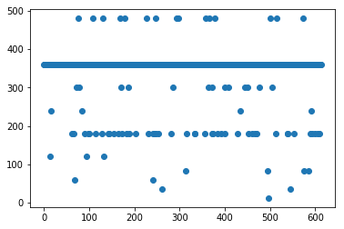

```python
CustomEncoder(loan_train_noid)
#AddAttribute(loan_train_noid)
numeric_features = list(loan_train_noid.dtypes[loan_train_noid.dtypes != 'object'].index)
loan_train_noid.head()
plt.plot(loan_train_noid.index, loan_train_noid.Loan_Amount_Term, 'o')
loan_train_noid.head()
```

```python
categoric_pipeline = Pipeline([
    ('selector', DataFrameSelector(attribute_names = categoric_features)),
    ('encoder', Encoder(attribute_names = categoric_features)),
])

numeric_pipeline = Pipeline([
    ('selector', DataFrameSelector(attribute_names = numeric_features)),
    ('imputer', Imputer(strategy='mean')),
    ('scaler', MinMaxScaler()),
])

def CombinedPipeline(data, numeric_pipeline, categoric_pipeline=None):

    if categoric_pipeline==None:
        return numeric_pipeline.fit_transform(data), data.columns

    x_num = numeric_pipeline.fit_transform(data)
    x_cat, categories = categoric_pipeline.fit_transform(data)

    x = np.c_[x_num, x_cat]

    return x, categories
```

```python
from sklearn.pipeline import FeatureUnion

full_pipeline = FeatureUnion(transformer_list=[
    ('numeric_pipeline', numeric_pipeline),
    ('categoric_pipeline', categoric_pipeline),
])

"""
The following won't work as it is because categoric_pipeline returns a tuple
rather than a single array. Hence, the concatenation step of FeatureUnion will
try to use a tuple and fail.

X = full_pipeline.fit_transform(loan_train_noid)

"""

X, categories = CombinedPipeline(loan_train_noid, numeric_pipeline, categoric_pipeline=None)
y = np.array([1 if value == 'Y' else 0 for value in labels]).reshape(-1, 1)

# We can reconstruct the entire dataFrame like this:
#all_features = list(numeric_features) + list(categories)
#X_df = pd.DataFrame(X, columns=all_features)
```

## Model Selection

Let's try a few models

- ### Logistic Regression

```python
from sklearn.linear_model import LogisticRegression, SGDClassifier
from sklearn.metrics import accuracy_score

lr_model = LogisticRegression(
    C = 1000,                    # Inverse regularization, high value means less regularization
    class_weight = 'balanced',   # To help to algorithm deal with class imbalance
    random_state = 0,            # For reproducibility

    ).fit(X, y)


#Make predictions using the train set
lr_y = lr_model.predict(X)

#calculate accuracy score on train set
print("Accuracy score {:6.2f}".format(accuracy_score(lr_y, y)))
```

```
Accuracy score   0.76
```

<hr style="height:1px";>

**Logistic Regression** performs not very good even on the train set. This may be a sign that the model is too simple and underfits the data. Possible solutions:

- Select a more complex model
- Reduce Regularization (this may not help in this case because we already have a pretty high value of C=1000)
- Select a better subset of features
- ### Decision Tree

```python
from sklearn.tree import DecisionTreeClassifier

tree_model = DecisionTreeClassifier(
    random_state = 0

    ).fit(X,y)


#Make predictions using the cross validation set
tree_y = tree_model.predict(X)

#calculate accuracy score on train set
print("Accuracy score {:6.2f}".format(accuracy_score(tree_y, y)))
```

```
Accuracy score   1.00
```

```python
tree_model = DecisionTreeClassifier(
    random_state = 0,
    max_depth  = 5,     #Helps to reduce overfitting
    ).fit(X,y)


#Make predictions using the cross validation set
tree_y = tree_model.predict(X)

#calculate accuracy score on train set
print("Accuracy score {:6.2f}".format(accuracy_score(tree_y, y)))
```

```
Accuracy score   0.83
```

<hr style="height:1px";>

**Default Decision Tree** is perfect on the train set. But let's not get too excited! Perfect scores usually mean that the model is overfitting the data. Possible solutions for overfitting:

- Select a less complex model
- increase Regularization (e.g. set the max_depth or other regularization parameters)
- Add the training set, collect more data (of course after exploring other options deeper)

```python
from sklearn.model_selection import train_test_split
from sklearn.model_selection import cross_val_score

#split the train set into train and cross validation sets
x_train, x_cv, y_train, y_cv = train_test_split(X, y, test_size = 0.2)

model = LogisticRegression(penalty = 'l1', C=1000, random_state=1)
_ = model.fit(x_train, y_train)

#Make predictions using the cross validation set
pred_cv = model.predict(x_cv)

#calculate accuracy score for the cross validation set
print("Accuracy score on train set {:6.2f}".format(model.score(x_train, y_train)))
print("Accuracy score on validation set {:6.2f}".format(model.score(x_cv, y_cv)))
scores = cross_val_score(model, X, y, cv = 10)
print("cross validation scores {:6.2f}".format(np.mean(scores)))
```

```
Accuracy score on train set   0.80
Accuracy score on validation set   0.84
cross validation scores   0.81
```

```python
tree_model = DecisionTreeClassifier(
    random_state = 0,
    max_depth  = 6,     #Helps to reduce overfitting

    ).fit(x_train, y_train)


#Make predictions using the cross validation set
tree_y = tree_model.predict(x_cv)

#calculate accuracy score for the cross validation set
print("Accuracy score on train set {:6.2f}".format(tree_model.score(x_train, y_train)))
print("Accuracy score on validation set {:6.2f}".format(tree_model.score(x_cv, y_cv)))
scores = cross_val_score(tree_model, X, y, cv = 10)
print("cross validation scores {:6.2f}".format(np.mean(scores)))
```

```
Accuracy score on train set   0.84
Accuracy score on validation set   0.84
cross validation scores   0.77
```

```python
from sklearn.svm import SVC

svc = SVC(C = 10, kernel = 'rbf').fit(x_train, y_train)

#Make predictions using the cross validation set
svc_y = svc.predict(x_cv)

#calculate accuracy score for the cross validation set
print("Accuracy score on train set {:6.2f}".format(svc.score(x_train, y_train)))
print("Accuracy score on validation set {:6.2f}".format(svc.score(x_cv, y_cv)))
scores = cross_val_score(svc, X, y, cv = 10)
print("cross validation scores {:6.2f}".format(np.mean(scores)))
```

```
Accuracy score on train set   0.80
Accuracy score on validation set   0.84
cross validation scores   0.81
```

```python
sgd = SGDClassifier(random_state=0).fit(x_train, y_train)

#Make predictions using the cross validation set
sdg_y = svc.predict(x_cv)

#calculate accuracy score for the cross validation set
print("Accuracy score on train set {:6.2f}".format(svc.score(x_train, y_train)))
print("Accuracy score on validation set {:6.2f}".format(svc.score(x_cv, y_cv)))
scores = cross_val_score(sgd, X, y, cv = 10)
print("cross validation scores", np.mean(scores))
```

```
Accuracy score on train set   0.80
Accuracy score on validation set   0.84
cross validation scores 0.7164454852979442
```

## Grid Search

```python
from sklearn.model_selection import GridSearchCV, RandomizedSearchCV
from scipy.stats import randint

#max_depth=None, min_samples_split=2, min_samples_leaf=1, min_weight_fraction_leaf=0.0,
#max_features=None, random_state=None, max_leaf_nodes=None,
#min_impurity_decrease=0.0, min_impurity_split=None, class_weight=None, presort=False

params_grid = {
    'max_depth':randint(low=1, high=10),
    }

#create an instance of the regressor
tree = DecisionTreeClassifier(random_state=0, class_weight = None)

rand_search = RandomizedSearchCV(tree,
                                 param_distributions=params_grid,
                                 n_iter=10,
                                 cv=5,
                                 random_state=0 )

rand_search.fit(X, y)
```

```
RandomizedSearchCV(cv=5, error_score='raise',
          estimator=DecisionTreeClassifier(class_weight=None, criterion='gini', max_depth=None,
            max_features=None, max_leaf_nodes=None,
            min_impurity_decrease=0.0, min_impurity_split=None,
            min_samples_leaf=1, min_samples_split=2,
            min_weight_fraction_leaf=0.0, presort=False, random_state=0,
            splitter='best'),
          fit_params=None, iid=True, n_iter=10, n_jobs=1,
          param_distributions={'max_depth': <scipy.stats._distn_infrastructure.rv_frozen object at 0x7fb63108f1d0>},
          pre_dispatch='2*n_jobs', random_state=0, refit=True,
          return_train_score='warn', scoring=None, verbose=0)
```

```python
rand_search.best_params_
```

```
{'max_depth': 1}
```

```python
cvres = rand_search.cv_results_
for mean_score, params in zip(cvres["mean_test_score"], cvres["params"]):
    print(mean_score, params)
```

```
0.7654723127035831 {'max_depth': 6}
0.8094462540716613 {'max_depth': 1}
0.7947882736156352 {'max_depth': 4}
0.7947882736156352 {'max_depth': 4}
0.742671009771987 {'max_depth': 8}
0.7947882736156352 {'max_depth': 4}
0.7654723127035831 {'max_depth': 6}
0.8029315960912052 {'max_depth': 3}
0.7752442996742671 {'max_depth': 5}
0.742671009771987 {'max_depth': 8}
```